# README

## 📉 How to Avoid Company Closure

### *A Data-Driven Survival Guide*

**Author:** Abeer Gaber  
**Date:** 2025-05-02

## 🔍 Overview

This project delves into the financial, stock, and operational data of companies to uncover critical patterns associated with their long-term success or potential closure. By leveraging real-world company data, this report provides actionable insights to help business owners identify early warning signs of failure and take proactive measures to sustain their operations.

## 📂 Dataset Description

The dataset includes key financial and performance metrics for various companies, offering a comprehensive view of their operational health. The following variables are included:

- **Status:** Indicates whether the company is active or closed.
- **Lifespan (duration):** The number of years the company operated.
- **Annual Revenue:** Yearly revenue data for each company.
- **P/E Ratio:** A financial metric used to assess the company’s valuation.
- **Average Stock Price:** Reflects the company’s stock performance over time.
- **Company Name and Year:** The identity and operational timeline of each company.

## 📊 Visualizations (R)

Several interactive and insightful visualizations are included to illustrate key findings:

- **Company Status Distribution:** A bar chart showing the number of active vs. closed and Re-Opened companies.
- **Company Lifespan Comparison:** A boxplot comparing the lifespan of companies that survived vs. those that closed.
- **Revenue Trends Over Time:** A line chart tracking revenue changes over the years for each company.
- **PE Ratio and Stock Price Correlation:** A scatter plot analyzing the relationship between P/E ratio and stock price.

## 📊 Statistical Analysis Visualizations

In-depth statistical analyses provide a clearer understanding of the factors influencing company survival:

- **Descriptive Statistics:** A summary of key metrics like revenue, stock price, and P/E ratio.
- **Correlation Analysis:** Investigates relationships between variables (e.g., revenue and net income).
- **Linear Regression (net_income ~ revenue):** Explores the impact of revenue on net income with a regression model.
- **Regression Line Plot:** A visual representation of the regression line to understand trends and deviations.
- **Prediction Model:** Forecasting Future Company Status.

## 📊 SQL-Based Financial Analysis

In addition to R-based visualizations, this project also includes an **SQL analysis** part that dives deeper into company performance across multiple financial aspects. The SQL queries explore:

- **Top Profitable Companies per Year:** Finding companies with the highest net income each year.
- **Average PE Ratio by Company Status:** Comparing active and closed companies.
- **Profit Margins:** Analyzing the percentage of net income relative to revenue.
- **Stock Price Analysis:** Identifying companies with above-average stock prices.
- **Revenue and Debt Comparison:** Understanding how revenue and long-term debt differ between surviving and closed companies.
- **Lowest Profitability in Recent Years:** Detecting companies at financial risk.
- **Profit Variability:** Measuring how much net income fluctuated over time.
- **Debt-to-Equity Ratio Insights:** Evaluating financial leverage.

> 📂 All SQL queries are provided in the file `company_data_analysis.sql`.

## 📈 Power BI Dashboards

Power BI was used to build dynamic dashboards that present real-time insights with user-friendly visuals:

- 📊 **Profit Trends and Forecasting**

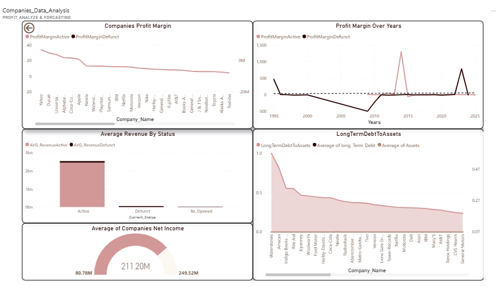

- 📉 **Status Breakdown by Year**

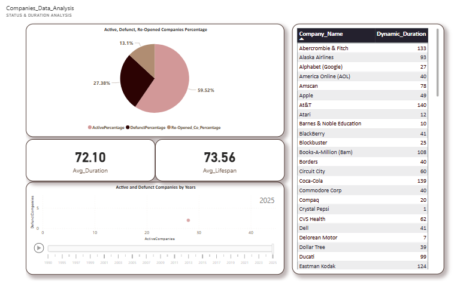

- 💵 **Operation & Market Performance**

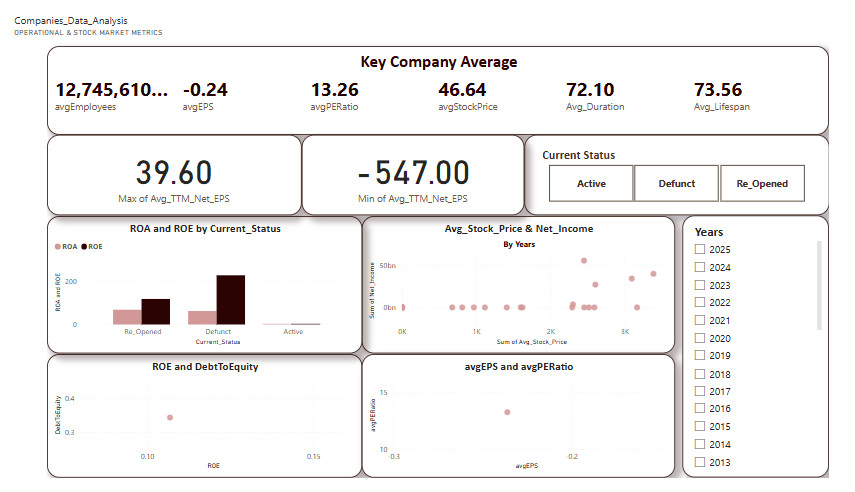

- ⚠️ **Warning Flags and Risk Prediction**

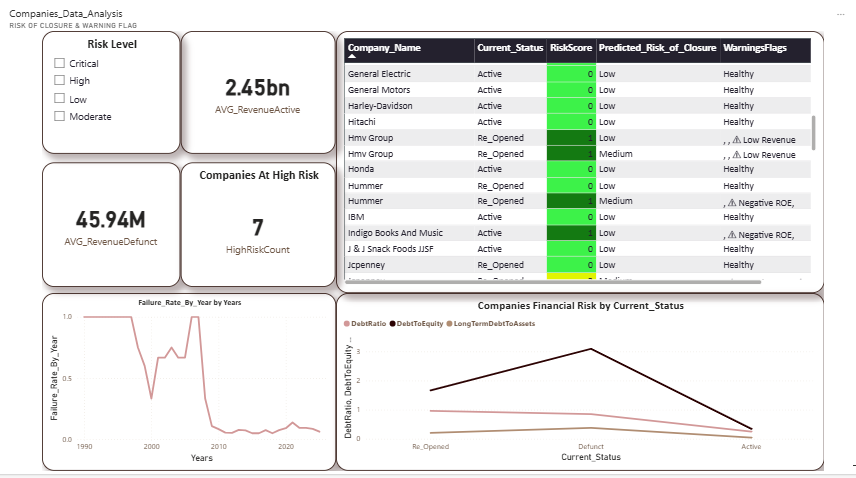

> 🎯 The Power BI file (`Companies_Data_Analysis.pbix`) is included for exploration.

## 📉 Excel-Based Analysis

Excel was used for data cleaning, sorting, conditional formatting, and creating pivot tables that highlight:

- **Revenue and Net Income Trends**
- **Top 10 Companies by Stock Price**
- **Year-over-Year Growth Summaries**
- **Interactive Slicers for Company Status and Year**

> 📂 Excel workbook included: `financial_summary_analysis.xlsx`

## 📌 Key Findings

- **Lifespan and Survival:** Surviving companies typically have much longer lifespans than those that close.
- **Revenue Fluctuations:** Companies experiencing significant revenue fluctuations or sharp declines are at a higher risk of closure.
- **PE Ratio Indicator:** A low P/E ratio often signals poor investor confidence and a higher likelihood of closure.
- **Critical Factors for Survival:** Adaptability, financial health, and innovation are crucial to ensuring a company’s survival in the long run.

## 🛠️ Tools Used

This analysis leverages the following tools and technologies: - **R** (ggplot2, dplyr, readr, knitr, openxlsx, tidyverse, readxl, janitor, lubridate, gridExtra, scales, tidyr, ggthemes, kableExtra, DT) - **MySQL Workbench** (for advanced SQL queries and financial insights) - **R Markdown:** For generating dynamic reports. - **CSV & Excel Files:** Cleaned and pre-processed data for analysis. - **Power Bi:** Create an interactive dashboard with slicers analyzing various type of companies data and predict closure and profit. - **Visualization & Insight Reporting:** A focus on creating clear and actionable insights through interactive visualizations.

## 🧭 How to Run This Report

1. Clone the repository or download the `.Rmd` and `.sql` files.
2. Open the R Markdown file in **RStudio** to view and run the R-based analysis.
3. Install the necessary R packages:

   ```r
   install.packages(c("ggplot2", "dplyr", "readr", "knitr", "openxlsx", "tidyverse", "readxl", "janitor", "lubridate", "gridExtra", "scales", "tidyr", "ggthemes", "kableExtra", "DT"))
   ```

4. Adjust the dataset

## 👩‍💻 About the Author

**Abeer Gaber**  
An aspiring Data Analyst with a passion for turning complex data into actionable business insights. I am skilled in R, Power BI, MySQL, and Excel, focusing on real-world applications related to business survival, financial health, and strategic decision-making.

## 📫 Contact

- 📧 **Email:** gaberabeer19@gmail.com
- 💼 **LinkedIn:** [linkedin.com/in/abeer-gaber-88a271118](https://www.linkedin.com/in/abeer-gaber-88a271118/)
- 🗂 **GitHub:** github.com/ABBERGABER-GITHUB

## 🧾 License

This project is licensed under the MIT License. See the LICENSE file for more information.

*Feel free to explore the project and reach out for collaboration or inquiries!*